# Exposure and Infection

Lecture Notes

2022-05-26

Library $\uparrow$ Hub $\rightarrow$ Malaria Epidemiology | Vignette

## $\odot$

We want to develop some mathematical theory describing the relationship between exposure and infection to support our analysis of complex malaria models. This essay starts by looking at the relationship between the FoI and the prevalence of malaria.

## SIS

### $\oplus$

We start with Ross’s model for infection, which is now called a *SIS* compartmental model, which has the following variables, parameters, and terms:

- Let $X$ denote the density of infected humans as a function of either age or time.
- Let $H$ denote human population density
- Let $r$ denote the rate parasites clear
- Let $h$ denote the FoI
- Let $x=X/H$ denote true prevalence

### Population

$$\frac{dX}{dt} = h(H-X) - r
X$$

which has the steady state

$$\bar x = \frac{h}{h+r}$$

which implies a scaling relationship between $h$ and $r.$ Since it is monotonic, it is invertible:

$$h = r \frac{\bar x}{1-\bar
x}$$

### Cohort

The SIS model is:

$$\frac{dX}{da} = h(H-X) - r
X$$

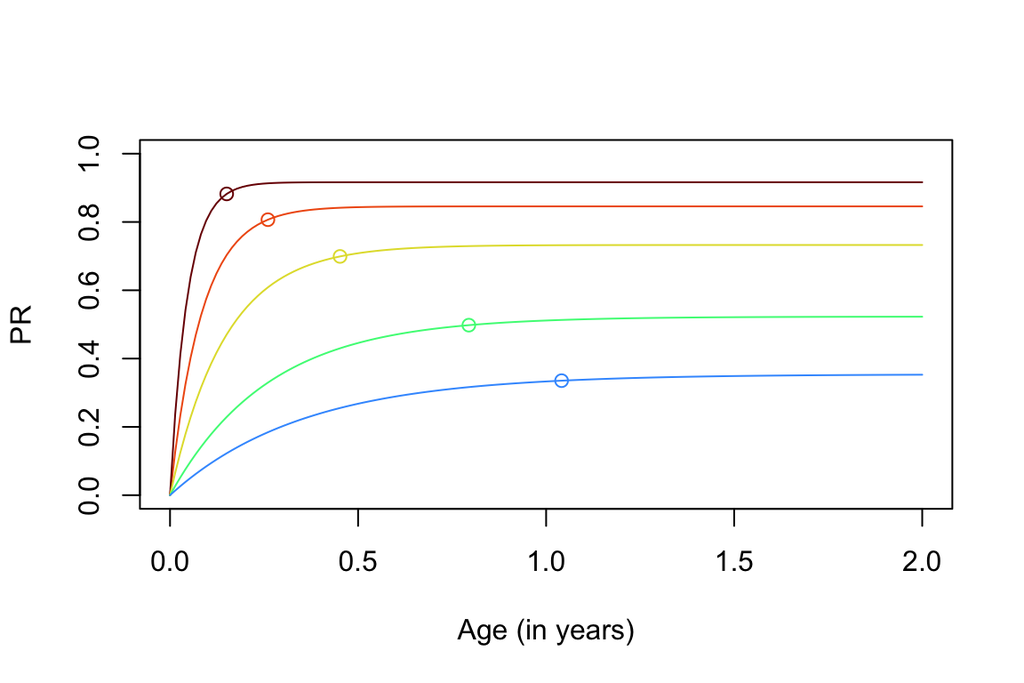

## Immunity

We can extend the skill set of the Ross-Macdonald model by adding a tracking variable. In malaria, immunity is a function of exposure and age. We add a tracking variable, $w$, that computes cumulative exposure:

$$\frac{dw}{da} = h$$

While $x$ is the true PR, we can let $\hat x$ denote the observed PR, where
$${\hat x} = F_x(x, w).$$

## Drugs

We can extend the previous model to include malaria treatment, followed by a brief period of chemo-protection. In this case, we model indiscriminate treatment, in part, because it makes the analysis very easy.

We assume that everyone who has not been treated recently gets treated at some rate, $\xi$ so there is a chemo-protected class $P$, and $U+X+ P = H$.

As a compartmental model:
$$\begin{array}{rl}
\frac{dU}{dt} &= \sigma P + r X - \xi U \\
\frac{dX}{dt} &= h U - (r+\xi) X \\
\frac{dP}{dt} &= \xi (X+U) - \sigma P \\
\end{array}$$

With this in place, we can reconsider our analysis of the steady states.

We note that $X+U = H-P.$ With a substitution, and letting $p=P/H$ denote the fraction that is chemo-protected, we get
$$\bar p = \frac{\xi}{\xi + \sigma}$$
and
$$\bar P = \frac{\xi}{\xi + \sigma}
H$$
and we can rewrite the remaining equations:

$$\begin{array}{rl}
\dot U &= \sigma \frac{\xi}{\xi+\sigma} H + r X - \xi U \\
\dot X &= h U - (r+\xi) X \\
\end{array}$$

It is only slightly modified:
$$\frac{\bar
x}{1- \bar p} = \frac{h}{h+r+\xi}$$

## $\dagger$

**Authors**

- David L Smith
- John M Henry
- Austin R Carter

**References**

1.

Smith DL, Guerra CA, Snow RW, Hay SI. Standardizing estimates of the *Plasmodium* *falciparum* parasite rate. Malar J. 2007;6: 131. doi:10.1186/1475-2875-6-131